# Løsning Utfodring 3.1.1

## Oppgave 3.1.1

Antakelser:

- Tone har nytte av sammensatt konsum og fritid. Hennes nytte kan beskrives ved bruk av nyttefunksjonen:

$$U(c,l) = c^\theta \cdot l^{1-\theta}$$
Vi antar at: $\theta = 0.5$

- Antall timer tilgjengelig for jobb per uke: $l_0 = 60$
- Arbeidsfri inntekt: $m = 100$
- Dersom Tone ikke jobber har hun tilgang til stønad (arbeidsledighesttrygd)
- Arbeidsmarkedet er “perfekt”

**Utled Tone sin statiske reservasjonslønn i disse to situasjonene:**

1. Stønaden er lik null,
2. Stønaden er lik 100.

Gjør rede for dine matematiske beregninger.

## Løsning oppgave 3.1.1. (kun matematikk og grafisk illustrasjon)

Reservasjonslønna er den lønn som gjør individet indifferent mellom det å jobbe og det å ikke jobbe. I den her situasjonen er reservasjonslønna den lønn som gjør Tone indifferent mellom det å jobbe $40$ timer ($h = 40, l = 20$) og det å ikke jobbe i det hele tatt ($h = 0, l = 60$). For at Tone skal være indifferent må nytten av å jobbe $40$ timer være lik nytten av å ikke jobbe i det hele tatt:

$$U(m+w^r\cdot h^{ft}, l_0 - h^{ft}) = U(m+s,l_0)$$
Ved bruk av den gitte nyttefunkjsonen har vi:
$$(m+w^r\cdot h^{ft})^\theta \cdot (l_0 - h^{ft})^{1-\theta} = (m+s)^\theta \cdot l_0^{1-\theta}$$

**Utledning av reservasjonslønn** Her utleder jeg nivået på reservasjonslønna generelt. I tilfellet da stønaden er lik null vil $s = 0$.

Målet mitt er å løse for $w^r$.Det går å løse problemet på mange måter. Jeg starter med å dividere med $(l_0 - h^{ft})^{1-\theta}$ på begge sider.
$$(m+w^r\cdot h^{ft})^\theta = (m+s)^\theta \cdot (\frac{l_0}{l_0 - h^{ft}})^{1-\theta}$$
Så hever jeg begge sider til $\frac{1}{\theta}$
$$m+w^r\cdot h^{ft} = (m+s) \cdot (\frac{l_0}{l_0 - h^{ft}})^{\frac{1-\theta}{\theta}}$$
Så trekker jeg ifra $m$ fra begge sider.
$$w^r\cdot h^{ft} = (m+s) \cdot (\frac{l_0}{l_0 - h^{ft}})^{\frac{1-\theta}{\theta}} - m$$
Nå må jeg bare dividere med $h^{ft}$ på begge sider for å finne $w^r$

$$w^r = \frac{(m+s) \cdot (\frac{l_0}{l_0 - h^{ft}})^{\frac{1-\theta}{\theta}} - m}{h^{ft}}$$
I tillfellet da $s = 0$ gis reservasjonslønna av:

$$w^r = \frac{m \cdot (\frac{l_0}{l_0 - h^{ft}})^{\frac{1-\theta}{\theta}} - m}{h^{ft}}$$
Vi kan nå sette inn tall.

Reservasjonslønn **uten** stønad:

$$w^r = \frac{100 \cdot (\frac{60}{60-40})^{\frac{1-0.5}{0.5}} - 100}{40}=\frac{100\cdot \frac{60}{20} - 100}{40}=\frac{200}{40} = 5$$
Reservasjonslønn **med** stønad:

$$w^r = \frac{(100 + 100) \cdot (\frac{60}{60-40})^{\frac{1-0.5}{0.5}} - 100}{40}=\frac{200\cdot \frac{60}{20} - 100}{40}=\frac{500}{40} = 12.5$$

Her nede viser jeg hvordan vi kan illustrere grafisk.Det første jeg gjør er å lage akser for tegningen

```r
# | warnings : false

library(tidyverse)

rm(list = ls())

l_1 <- seq(0, 60, by = .01)


df <- data.frame(l_1)


axes_1 <- ggplot(df, aes(l_1))+
  labs(x="Fritid", y="Konsum i 10-tall") +
  theme(axis.title = element_text(size = 10),
        plot.title = element_text(size = 10),
        panel.background = element_blank(), # hvit bakgrunn
        axis.line = element_line(colour = "black"), # sett inn akselinjer
        axis.title.x = element_text(hjust = 1),
        axis.title.y = element_text(angle = 0, vjust = 1, hjust=1))+ # juster labels på aksene
  coord_fixed(ratio = 1)+ # lik skala for x og y aksen
  scale_x_continuous(limits = c(0, 70), expand = c(0, 0))+
  scale_y_continuous(limits = c(0, 1000), expand = c(0, 0))+ # begrense aksene
  coord_fixed(ratio = (70 - 0) / (1000 - 0))
```

Deretter definerer jeg indifferansekurver for relevante nyttenivåer. For å finne ut hvilke nyttenivåer som er relevante, må jeg beregne nyttenivået da Tone velger å ikke jobbe i det hele tatt i de to situasjonene (med og uten stønad)

Nyttenivå ved $l = l_0$ ($l=60$), og $c=m$ ($c = 100$):
$$U(m,l_0) = 100^{0.5} \cdot 60^{0.5} \approx 77.45967$$
Nyttenivå ved $l = l_0$ ($l=60$), og $c=m + s$ ($c = 200$):
$$U(m,l_0) = 200^{0.5} \cdot 60^{0.5} \approx 109.54451$$
Indifferansekurvene skal tegnes i graf-området. Vår graf har to akser, $c$ og $l$. Vi må derfor skrive om ligningene slik at vi får $c$ som en funksjon av $l$, gitt at nivået på nytten er konstant og lik det vi har beregnet. For å se hvordan vi gjør dette kan det være flott å skrive om ligningene her oppe på mer generell form:

$$c^\theta \cdot l^{1-\theta} = \bar{U}$$
For å skrive $c$ som en funksjon av $l$ (og $\bar{U}$), så dividerer jeg med $l^{1-\theta}$ og hever begge sider til $1/\theta$:

$$c=\frac{\bar{U}^{\frac{1}{\theta}}}{l^\frac{1-\theta}{\theta}}$$

Vår antakelse om at $\theta = 0.5$ fører til at uttrykket blir mye enklere:

$$c=\frac{\bar{U}^2}{l}$$
Vi kan nå sette inn våre tall (nyttenivået med og uten stønad da Tone ikke velger å jobbe), og beregne indifferansekurvene.

```r
# nyttefunkjsonen som brukes U=c^.5x l^.5 (Cobb-Douglas)

# Indifferansekurver for relevante nyttenivåer (nytte ved l = l0 med og uten stønad)
I_0 <- function(l_1) (77.4596669241483^2)/(l_1)  # nytte uten stønad =  77.4596669241483
I_1 <- function(l_1) (109.544511501033^2)/(l_1) # nytte med stønad= 109.544511501033
```

Nå må jeg legge til kurver for reservasjonslønna. For å få dette til må jeg ta fram en ligning som lager en budsjettbetingelse gitt at $w = w^r$ i de to situasjonene. For å få fram skjæringspunktet med Y-aksen ($c$) må jeg beregne maks nivå på konsum. Dette får jeg fram ved å beregne konsum da Tone jobber alle timer hun har tilgjengelig. Husk at Tone ikke har tilgang til stønad dersom hun jobber!

```r
# Reservasjonslønn uten stønad
wr_uten <- function(l_1) {
  return(400 - 5 * l_1)
}

wr_med <- function(l_1) {
  return(850 - 12.5 * l_1)
}
```

Nå er jeg klar til å lage figuren min.

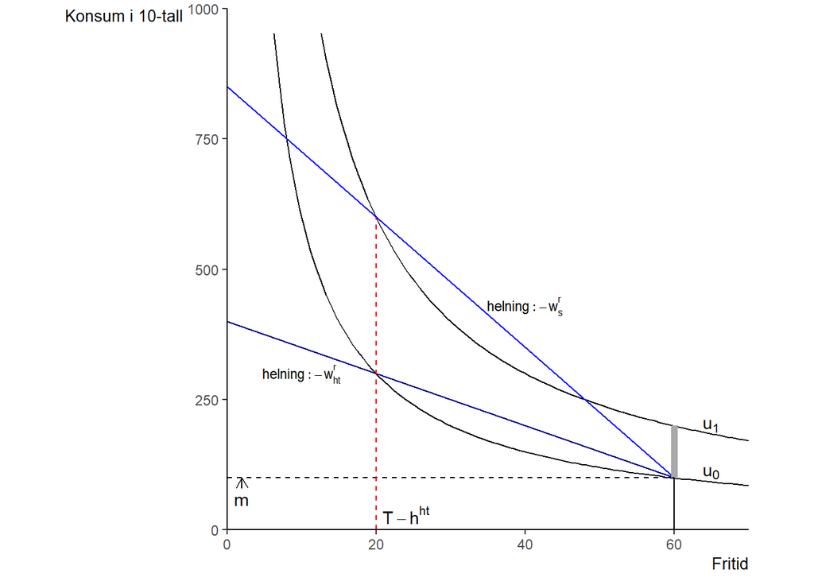

```r
figur_1 <- axes_1+
  stat_function(df,
                fun=I_0,
                mapping = aes() # Indifferansekurve 1
  )+
  stat_function(df,
                fun=I_1,
                mapping = aes() # Indifferansekurve 2
  )+
  annotate("text",
           x=65,
           y=110,
           label=expression(u[0]))+ # Navn og plassering av navnet I_0
  annotate("text",
           x=65,
           y=200,
           label=expression(u[1]))+ # Navn og plassering av navnet I_0
  geom_segment(aes(x = 0, y = wr_uten(0), xend = 60, yend = wr_uten(60)), color="darkblue") + # Kurve som beskriver budsjettbetingelsen ved w^r UTEN stønad
  annotate("text", x=10,y=300, size = 3,
           label= expression(helning: -w[ht]^{r}))+
  geom_segment(aes(x = 0, y = wr_med(0), xend = 60, yend = wr_med(60)), color="blue") +# Kurve som beskriver budsjettbetingelsen ved w^r MED stønad
  annotate("text",x=40,y=430, size = 3,
           label= expression(helning: -w[s]^{r}))+
  geom_segment(aes(x=60, y=0, xend=60, yend=100))+ # Segment som viser arbeidsfri privat inntekt (m) - vertikal linje
  geom_segment(aes(x=60, y=100, xend=60, yend=200), color="darkgray", linewidth=2)+ #Segment som viser stønaden - vertikal linje
  geom_segment(aes(x=0, y=100, xend=60, yend=100), linetype="dashed")+ #Segment som viser arbeidsfri privat inntekt - horisontal linje
  annotate("text",x=2,y=60,
           label="m")+
  geom_segment(aes(x=2, y=80, xend=2, yend=100),
    arrow = arrow(length = unit(0.25, "cm")))+
  geom_segment(aes(x=20, y=0, xend=20, yend=600), linetype="dashed", color="red")+
  annotate("text",x=24,y=30,
           label=expression(T-h^{ht}))

figur_1
```